# Chapter 9: Likelihood-Based Inference and Estimation

2026-02-25

# 1 Likelihood Theory

## 1.1 Likelihood vs Probability

These two concepts are often confused, but they answer fundamentally different questions:

| Concept | Question answered | What varies | What is fixed |
| --- | --- | --- | --- |
| **Probability** | How likely is this *data* given these parameters? | Data (outcomes) | Parameters |
| **Likelihood** | How well do these *parameters* explain this data? | Parameters | Data (observed) |

Formally, for a parameter $\theta$ and observed data $\mathbf{x}$:

$$\mathcal{L}(\theta \mid \mathbf{x}) =
P(\mathbf{x} \mid \theta)$$

The **same mathematical expression** is interpreted differently: as a probability (varying $\mathbf{x}$, fixed $\theta$) or as a likelihood (varying $\theta$, fixed $\mathbf{x}$).

> **Intuition:** You find footprints in the snow. Probability asks *“given this animal, how likely are these tracks?”* Likelihood asks *“given these tracks, which animal most likely made them?”*

## 1.2 Maximum Likelihood Principle

The **Maximum Likelihood Estimator (MLE)** $\hat{\theta}$ is the parameter value that makes the observed data *most probable*:

$$\hat{\theta} = \arg\max_{\theta}\;
\mathcal{L}(\theta \mid \mathbf{x})$$

**Key idea:** Among all possible parameter values, choose the one that gives the observed data the highest probability of occurring.

# 2 MLE Construction

## 2.1 Likelihood Functions

For $n$ independent observations from the same distribution with parameter $\theta$, the **joint likelihood** is the product of individual densities/probabilities:

$$\mathcal{L}(\theta \mid x_1, \ldots,
x_n) = \prod_{i=1}^{n} f(x_i \mid \theta)$$

**Example — Normal likelihood** (unknown $\mu$, known $\sigma = 1$):

$$\mathcal{L}(\mu \mid \mathbf{x}) =
\prod_{i=1}^{n} \frac{1}{\sqrt{2\pi}} \exp\!\left(-\frac{(x_i -
\mu)^2}{2}\right)$$

## 2.2 Log-Likelihoods

Products over many observations quickly become numerically tiny (floating-point underflow). Taking the **logarithm** converts the product into a sum and preserves the location of the maximum:

$$\ell(\theta \mid \mathbf{x}) = \log
\mathcal{L}(\theta \mid \mathbf{x}) = \sum_{i=1}^{n} \log f(x_i \mid
\theta)$$

Since $\log$ is monotone increasing:
$$\arg\max_\theta\;
\mathcal{L}(\theta) = \arg\max_\theta\; \ell(\theta)$$

> **Why log?** Sums are numerically stable and analytically simpler than products — derivatives of sums are sums of derivatives.

## 2.3 Derivatives and Optimisation Logic

To find the MLE analytically, differentiate the log-likelihood with respect to $\theta$ and set equal to zero:

$$\frac{d\ell}{d\theta} = 0 \quad
\Rightarrow \quad \hat{\theta}_{\text{MLE}}$$

Confirm it is a maximum (not minimum) by checking the second derivative is negative:

$$\frac{d^2\ell}{d\theta^2}\bigg|_{\hat{\theta}}
< 0$$

# 3 Analytical MLEs

## 3.1 Normal Distribution Parameters

Given $X_i \sim \mathcal{N}(\mu, \sigma^2)$, the log-likelihood is:

$$\ell(\mu, \sigma^2) =
-\frac{n}{2}\log(2\pi\sigma^2) - \frac{1}{2\sigma^2}\sum_{i=1}^n (x_i -
\mu)^2$$

Solving $\partial\ell/\partial\mu = 0$ and $\partial\ell/\partial\sigma^2 = 0$:

$$\hat{\mu}_{\text{MLE}} = \bar{x} =
\frac{1}{n}\sum x_i \qquad \hat{\sigma}^2_{\text{MLE}} =
\frac{1}{n}\sum(x_i - \bar{x})^2$$

> **Note:** $\hat{\sigma}^2_{\text{MLE}}$ divides by $n$, not $n-1$. It is a **biased** estimator of the population variance. The unbiased sample variance $s^2$ uses $n-1$ (Bessel’s correction from Chapter 2).

## 3.2 Poisson Parameter Estimation

Given $X_i \sim \text{Poisson}(\lambda)$, the log-likelihood is:

$$\ell(\lambda) = \sum_{i=1}^n x_i \cdot
\log\lambda - n\lambda - \sum_{i=1}^n \log(x_i!)$$

Setting $d\ell/d\lambda = 0$:

$$\hat{\lambda}_{\text{MLE}} =
\bar{x}$$

The MLE of the Poisson rate is simply the sample mean — elegant and intuitive.

## 3.3 MLE vs Unbiased Estimators

| Property | MLE | Unbiased Estimator |
| --- | --- | --- |
| **Definition** | Maximises likelihood | Expected value = true parameter |
| **Bias** | Can be biased (e.g. $\hat{\sigma}^2$) | Zero bias by construction |
| **Variance** | Achieves Cramér-Rao lower bound (efficient) | May have higher variance |
| **Consistency** | $\hat{\theta} \to \theta$ as $n \to \infty$ | Usually consistent |
| **Asymptotic normality** | $\hat{\theta} \approx \mathcal{N}(\theta, 1/\mathcal{I}(\theta))$ | Varies |

> **Bottom line:** MLE trades a small bias for lower variance. For large $n$, the bias vanishes and MLE is optimal. For small $n$, prefer unbiased estimators like $s^2$.

# 4 R Coverage

## 4.1 Writing Likelihood Functions Manually

```r
# Log-likelihood for Normal distribution with known σ = 1
# We vary μ and see how the likelihood changes

log_likelihood_normal <- function(mu, data = obs_data, sigma = 1) {
  sum(dnorm(data, mean = mu, sd = sigma, log = TRUE))
}

# Test at a few candidate values of μ
candidate_mus <- c(9, 10, 11, 11.6, 12, 13)
ll_values     <- sapply(candidate_mus, log_likelihood_normal)

data.frame(mu = candidate_mus,
           log_likelihood = round(ll_values, 4))
```

```
#>     mu log_likelihood
#> 1  9.0       -24.0947
#> 2 10.0       -13.5947
#> 3 11.0        -8.0947
#> 4 11.6        -7.1947
#> 5 12.0        -7.5947
#> 6 13.0       -12.0947
```

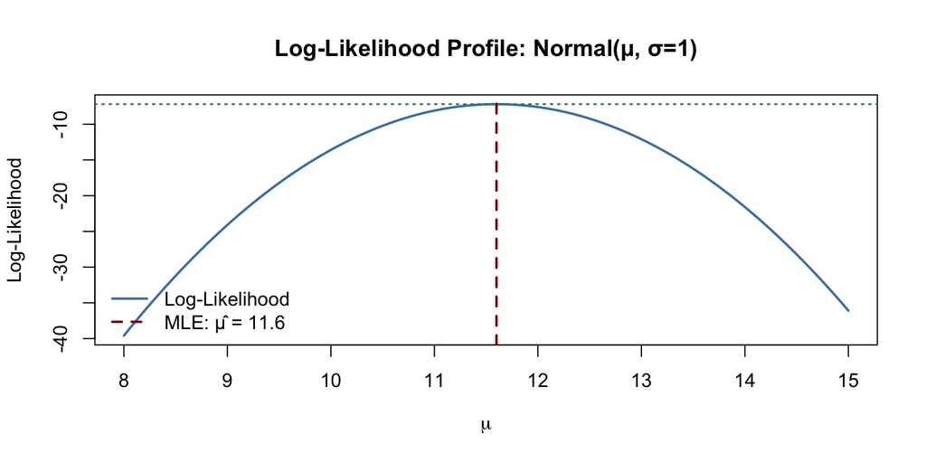

```r
# Plot the full likelihood profile across a range of μ values
mu_grid  <- seq(8, 15, length.out = 200)
ll_grid  <- sapply(mu_grid, log_likelihood_normal)

plot(mu_grid, ll_grid,
     type = "l", lwd = 2, col = "steelblue",
     main = "Log-Likelihood Profile: Normal(μ, σ=1)",
     xlab = expression(mu),
     ylab = "Log-Likelihood")

# Mark the MLE (should equal the sample mean)
mle_mu <- mean(obs_data)
abline(v  = mle_mu, col = "darkred",  lwd = 2, lty = 2)
abline(h  = log_likelihood_normal(mle_mu),
       col = "seagreen", lwd = 1.5, lty = 3)

legend("bottomleft",
       legend = c("Log-Likelihood", paste0("MLE: μ̂ = ", mle_mu)),
       col    = c("steelblue", "darkred"),
       lty    = c(1, 2), lwd = 2, bty = "n")
```

## 4.2 Using `optim()` to Find the MLE

When analytical solutions are unavailable, use numerical optimisation. `optim()` *minimises* by default, so we pass the **negative** log-likelihood.

```r
neg_log_lik <- function(mu) -log_likelihood_normal(mu)

# Starting guess for μ
result <- optim(par    = 10,           # initial guess
                fn     = neg_log_lik,
                method = "Brent",      # 1D optimisation
                lower  = 5,
                upper  = 20)

cat("MLE via optim()    :", round(result$par, 6), "\n")
```

```
#> MLE via optim()    : 11.6
```

```r
cat("MLE via sample mean:", mean(obs_data), "\n")
```

```
#> MLE via sample mean: 11.6
```

```r
cat("Converged?         :", result$convergence == 0, "\n")
```

```
#> Converged?         : TRUE
```

## 4.3 Comparing Likelihood at Different Parameter Values

Visually comparing likelihood across candidates builds intuition for what “most likely” means.

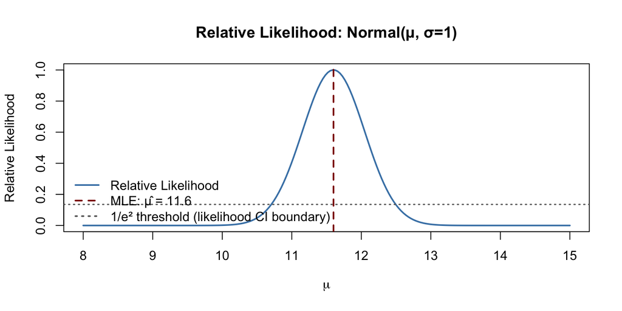

```r
# Convert log-likelihood to likelihood (exponentiate) for visualisation
# Normalise so the maximum = 1 (relative likelihood)
ll_rel <- exp(ll_grid - max(ll_grid))

plot(mu_grid, ll_rel,
     type = "l", lwd = 2, col = "steelblue",
     main = "Relative Likelihood: Normal(μ, σ=1)",
     xlab = expression(mu),
     ylab = "Relative Likelihood")

abline(v = mle_mu, col = "darkred", lwd = 2, lty = 2)
abline(h = exp(-2), col = "grey40", lwd = 1.5, lty = 3)

legend("bottomleft",
       legend = c("Relative Likelihood",
                  paste0("MLE: μ̂ = ", mle_mu),
                  "1/e² threshold (likelihood CI boundary)"),
       col    = c("steelblue", "darkred", "grey40"),
       lty    = c(1, 2, 3), lwd = 2, bty = "n")
```

> **Likelihood-based CI:** The range of $\mu$ values where relative likelihood $\geq e^{-2} \approx 0.135$ forms an approximate 95% **likelihood interval** for $\mu$ — a useful alternative to t-based confidence intervals.

## 4.4 `mle()` from the `stats4` Package

```r
library(stats4)

# Define negative log-likelihood as a function of mu
nll <- function(mu) -log_likelihood_normal(mu)

# mle() finds the minimum of nll (= maximum of log-likelihood)
mle_fit <- mle(nll, start = list(mu = 10))

summary(mle_fit)
```

```
#> Maximum likelihood estimation
#>
#> Call:
#> mle(minuslogl = nll, start = list(mu = 10))
#>
#> Coefficients:
#>    Estimate Std. Error
#> mu     11.6  0.4472136
#>
#> -2 log L: 14.38939
```

```r
# Likelihood-based confidence interval from profile likelihood
confint(mle_fit)
```

```
#> Profiling...
```

```
#>    2.5 %   97.5 %
#> 10.72348 12.47652
```

# 5 Chapter Summary

| Concept | Key Takeaway |
| --- | --- |
| Likelihood $\mathcal{L}(\theta \mid \mathbf{x})$ | How well does $\theta$ explain the observed data? |
| vs Probability | Probability varies data; likelihood varies parameters |
| MLE $\hat{\theta}$ | Parameter value that maximises $\mathcal{L}$ (or $\ell$) |
| Log-likelihood $\ell$ | Log of $\mathcal{L}$; sum replaces product; same optimum |
| Normal MLE | $\hat{\mu} = \bar{x}$; $\hat{\sigma}^2 = \frac{1}{n}\sum(x_i-\bar{x})^2$ (biased) |
| Poisson MLE | $\hat{\lambda} = \bar{x}$ |
| MLE bias | MLE $\hat{\sigma}^2$ uses $n$; unbiased $s^2$ uses $n-1$ |
| MLE efficiency | Achieves minimum possible variance (Cramér-Rao bound) for large $n$ |
| R: `dnorm(..., log=TRUE)` | Computes log-density; sum over observations = log-likelihood |
| R: `optim()` | Numerical MLE; minimise negative log-likelihood; check `convergence == 0` |
| R: `mle()` (stats4) | Higher-level MLE with automatic SE and profile CI via `confint()` |
| Likelihood interval | Range where relative likelihood $\geq e^{-2}$ ≈ 95% CI alternative |